# Statistica e Laboratorio: esercizi

## A) Statistica descrittiva

### A.1)

Nella seguente tabella sono riportate le lunghezze di 40 foglie di platano, registrate al millimetro più prossimo:

| 138 | 164 | 150 | 132 | 144 | 125 | 149 | 157 |
| --- | --- | --- | --- | --- | --- | --- | --- |
| 146 | 158 | 140 | 147 | 136 | 148 | 152 | 144 |
| 168 | 126 | 138 | 176 | 163 | 119 | 154 | 165 |
| 146 | 173 | 142 | 147 | 135 | 153 | 140 | 135 |
| 161 | 145 | 135 | 142 | 150 | 156 | 145 | 128 |

Si definisca la variabile Y, oggetto di interesse, e si dica se è qualitativa, sconnessa o ordinale, o quantitativa, discreta o continua. Con riferimento ai risultati della rilevazione, si specifi chi la associata variabile statistica e si individui il suo supporto. Dopo aver definito le seguenti classi di modalità di ampiezza 10 mm, 118 ⊣ 128, 128 ⊣ 138,· · · , 168 ⊣ 178, si specifi chi la distribuzione di frequenza assoluta e relativa e le corrispondenti frequenze cumulate. Si costruiscano le rappresentazioni grafiche mediante l’istogramma e il poligono di frequenza. Inoltre, si determini la moda, la mediana e la media aritmetica di Y e si esprima un parere sulla simmetria della distribuzione di frequenza. Si calcolino i quantili di livello α = 0.25 e α = 0.75 e si costruisca la rappresentazione grafica mediante il diagramma a scatola e baffi. Infine, si calcoli il campo di variazione, lo scarto interquartilico, la varianza e il coefficiente di variazione.

#### Risoluzione:

La variabile è ordinabile

#### Creiamo la tabella:

[output not shown]

#### Rappresentazione grafica:

per l'istogramma va trovata l'area occupata da ognuna classe, in questo caso avendo tutte la medesima base (un intervallo di 10mm) viene valutata solo l'altezza. Per fare ciò possiamo associare il valore f con h:

[output not shown]

Per il grafico di frequenza basta unire i punti medi della cima di ogni barra (non lo farò con html)

#### Moda, mediana, media e simmetria della distribuzione di frequenza:

  per ottenere la deviazione standard: \( σ=\frac{\sum_{i=1}^{n}(x_i -\overline{x})^2}{n} \)

  sostiutendo i valori: \( σ=12.8864 mm \)

#### riscriviamolo con il codice:

```python
valori <- c(
  138, 164, 150, 132, 144, 125, 149, 157,
  146, 158, 140, 147, 136, 148, 152, 144,
  168, 126, 138, 176, 163, 119, 154, 165,
  146, 173, 142, 147, 135, 153, 140, 135,
  161, 145, 135, 142, 150, 156, 145, 128
)

# Definizione degli intervalli
breaks <- seq(118, 178, by = 10)  # crea 118, 128, 138, 148, 158, 168, 178

# Conta quanti valori cadono in ciascun intervallo
frequenze <- hist(valori, breaks = breaks, plot = FALSE)$counts
f <- frequenze                    # frequenza assoluta
F <- f / length(valori)           # frequenza relativa
p <- cumsum(f)                    # frequenza assoluta cumulata
P <- cumsum(F)                    # frequenza relativa cumulata

# Stampa risultati
tabella <- data.frame(
  Intervallo = paste(head(breaks, -1), "⊣", tail(breaks, -1)),
  f = f,
  F = F,
  p = p,
  P = P
)

print(tabella)
```

```
  Intervallo  f     F  p     P
1  118 ⊣ 128  4 0.100  4 0.100
2  128 ⊣ 138  7 0.175 11 0.275
3  138 ⊣ 148 13 0.325 24 0.600
4  148 ⊣ 158  9 0.225 33 0.825
5  158 ⊣ 168  5 0.125 38 0.950
6  168 ⊣ 178  2 0.050 40 1.000
```

### A.2)

Si sono rilevati i guasti meccanici riportati da 40 autovetture FIAT e da 60 autovetture OPEL, possedute da una azienda di spedizioni, nei primi 50.000 Km di percorrenza. I dati sono sintetizzati nella seguente tabella che riporta le frequenze assolute:

| No. guasti | Autovetture FIAT | Autovetture OPEL |
| --- | --- | --- |
| 0 | 9 | 33 |
| 1 | 13 | 20 |
| 2 | 10 | 6 |
| 3 | 5 | 1 |
| 4 | 3 | 0 |
| Totale | 40 | 60 |

Si definisca la variabile Y , oggetto di interesse, e si dica se è qualitativa, sconnessa o ordinale, o quantitativa, discreta o continua. Con riferimento ai risultati della rilevazione, sintetizzati nella tabella di frequenza, si specifichino le due variabili statistiche ed i rispettivi supporti. Si determinino le distribuzioni di frequenza relativa e si costruiscano le rappresentazioni grafiche mediante diagrammi con bastoncini. Si calcolino le frequenze cumulate, relative e assolute, delle due variabili statistiche. Inoltre, si determinino la moda, la mediana e la media aritmetica e si calcolino la varianza e il coefficiente di variazione. Si esprima un parere sul confronto tra le due popolazionidi autovetture.

#### Definizione variabile Y e proprietà:

La variabile Y da tenere in considerazione è il numero di autovetture per ciascun numero di guasti (seconda e terza colonna) ed è quantitiativa

#### Rappresentazioni grafiche mediante diagrammi con bastoncini della distribuzione e frequenza:

| No. guasti | Autovetture FIAT (F) | Autovetture OPEL (F) |
| --- | --- | --- |
| 0 | 0,225 | 0,55 |
| 1 | 0,325 | \(0,\overline{3}\) |
| 2 | 0,25 | 0,1 |
| 3 | 0,125 | \(0,01\overline{6}\) |
| 4 | 0,075 | 0 |
| Totale | 1 | 1 |

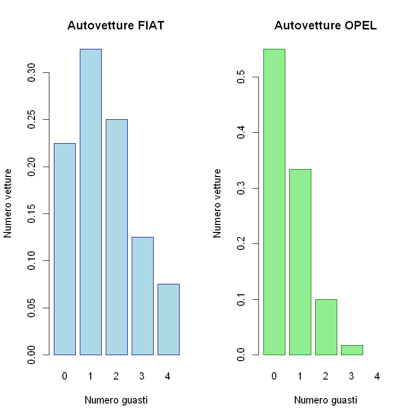

```python
par(mfrow = c(1, 2))

valori_fiat <- c(0.225, 0.325, 0.25, 0.125, 0.075)
nomi <- c("0", "1", "2", "3", "4")

barplot(valori_fiat, names.arg = nomi,
        main = "Autovetture FIAT",
        xlab = "Numero guasti",
        ylab = "Numero vetture",
        col = "lightblue",
        border = "darkblue")

# --- Secondo grafico ---
valori_opel <- c(0.55, 0.33333, 0.1, 0.0166667, 0)

valori_opel[valori_opel == 0] <- NA  # Turn zeros into NA

barplot(valori_opel, names.arg = nomi,
        main = "Autovetture OPEL",
        xlab = "Numero guasti",
        ylab = "Numero vetture",
        col = "lightgreen",
        border = "darkgreen")

par(mfrow = c(1, 1))
```

#### Frequenze cumulate, relative e assolute, delle due variabili statistiche:

Autovetture FIAT

| No. guasti | f | F | p | P |
| --- | --- | --- | --- | --- |
| 0 | 9 | 0,225 | 9 | 0,225 |
| 1 | 13 | 0,325 | 22 | 0,55 |
| 2 | 10 | 0,25 | 32 | 0,8 |
| 3 | 5 | 0,125 | 37 | 0,925 |
| 4 | 3 | 0,075 | 40 | 1 |
| Totale | 40 | 1 | 40 | 1 |

Autovetture OPEL

| No. guasti | f | F | p | P |
| --- | --- | --- | --- | --- |
| 0 | 33 | 0,55 | 33 | 0,55 |
| 1 | 20 | 0,3 | 53 | 0,88 |
| 2 | 6 | 0,1 | 59 | 0,98 |
| 3 | 1 | 0,016 | 60 | 1 |
| 4 | 0 | 0 | 60 | 1 |
| Totale | 60 | 1 | 60 | 1 |

#### Moda, la mediana e la media aritmetica e si calcolino la varianza e il coefficiente di variazione:

[output not shown]

Per ottenere lo scarto quadrato medio si usa la formula:

\(V(Y)=\frac{1}{n}\sum_{i=1}^{n}(y_i-E(Y))^2 \)

Sostuidendo con i valori:

Autovetture FIAT:

\(V(Y)=\frac{1}{40}\cdot( (9\cdot(0-1,5)^2) + (13\cdot(1-1,5)^2) +(10\cdot(2-1,5)^2) +(5\cdot(3-1,5)^2) +(3\cdot(4-1,5)^2) )=1,4 \)

Per il coeficente di variazione:

\( σ_A = \sqrt{1,4}≈1,183 \)

\( CV=\frac{σ}{\overline{Y}}\cdot100 = \frac{1,183}{1,5}\cdot100=78,9\% \)

Autovetture OPEL:

\(V(v)=\frac{1}{60}\cdot(33\cdot(0-0,583)^2 + 20\cdot(1-0,583)^2 + 6\cdot(2-0,583)^2+ 1\cdot(3-0,583)^2+ 0\cdot(4-0,583)^2)≈0,543 \)

Per il coeficente di variazione:

\( σ_A = \sqrt{0,543}≈0.737 \)

\( CV=\frac{σ}{\overline{Y}}\cdot100 = \frac{0.737}{0,583}\cdot100=126,4\% \)

Dall’analisi dei dati emerge che le autovetture OPEL presentano un numero medio di guasti inferiore (0,583 rispetto a 1,5 per le autovetture FIAT), risultando quindi mediamente più affidabili. Tuttavia, il loro coefficiente di variazione (126,4%) è maggiore rispetto a quello delle autovetture FIAT (78,9%), il che indica che la distribuzione dei guasti tra i diversi veicoli OPEL è più disomogenea: alcune vetture non presentano alcun guasto, mentre altre mostrano più problemi. In sintesi, le autovetture OPEL sono mediamente più affidabili, ma mostrano una maggiore variabilità individuale nei risultati rispetto alle FIAT.

### A.3)

Le votazioni finali in centesimi riportate da 80 studenti in un test di ammissione al Corso di Laurea in Biotecnologie, sono registrate nella seguente tabella:

votazioni finali

| 68 | 84 | 75 | 82 | 68 | 90 | 62 | 88 | 76 | 93 |
| --- | --- | --- | --- | --- | --- | --- | --- | --- | --- |
| 73 | 79 | 88 | 73 | 60 | 93 | 71 | 59 | 85 | 75 |
| 61 | 65 | 75 | 87 | 74 | 62 | 95 | 78 | 63 | 72 |
| 66 | 78 | 82 | 75 | 94 | 77 | 69 | 74 | 68 | 60 |
| 96 | 78 | 89 | 61 | 75 | 95 | 60 | 79 | 83 | 71 |
| 79 | 62 | 67 | 97 | 78 | 85 | 76 | 65 | 71 | 75 |
| 65 | 80 | 73 | 57 | 88 | 78 | 62 | 76 | 53 | 74 |
| 86 | 67 | 73 | 81 | 72 | 63 | 76 | 75 | 85 | 77 |

Si definisca la variabile Y, oggetto di interesse, e si dica se è qualitativa, sconnessa o ordinale, o quantitativa, discreta o continua. Con riferimento ai risultati della rilevazione, si specifichi la associata variabile statistica e si individui il suo supporto. Si specifichi la distribuzione di frequenza assoluta e relativa e le corrispondenti frequenze cumulate, introducendo, se risulta opportuno, un conveniente raggruppamento delle modalità contigue in classi. Si calcoli la frequenza relativa di studenti che hanno riportato una votazione più alta di 65 e inferiore a 85. Si proponga una utile rappresentazione grafica per la distribuzione di frequenza relativa. Inoltre, si determini la moda, la mediana e la media aritmetica di Y , si calcolino i quantili di livello α=0.25 e α=0.75 e si costruisca la rappresentazione graficamediante il diagramma a scatola e baffi. Infine, si calcoli il campo di variazione, lo scarto interquartilico, la varianza e il coefficiente di variazione.

#### Definizione della variabile e proprietà:

la variabile Y di interesse è il voto finale, variabile quantitativa discreta.

#### Distribuzione di frequenza Assoluta e frequenze cumulate e raggruppamento

[output not shown]

#### Raggruppamento voto più alto di 65 e inferiore a 85:

il numero di studenti nell'intervallo è: \(F:\frac{46}{80}=0.575=57.5\%\)

#### Rappresentazione grafica per la distribuzione di frequenza relativa:

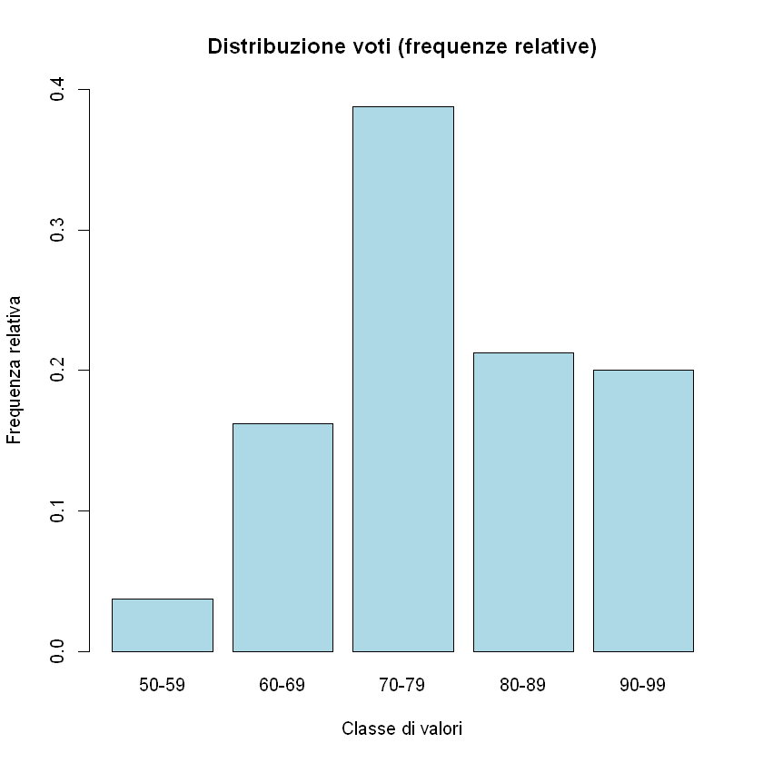

```python
intervalli = c("50-59", "60-69", "70-79","80-89","90-99")
valori = c(3,13,31,17,16)
# compute relative frequencies
rel_freq <- valori / sum(valori)

# plot
barplot(rel_freq,
        names.arg = intervalli,
        main = "Distribuzione voti (frequenze relative)",
        xlab = "Classe di valori",
        ylab = "Frequenza relativa",
        col = "lightblue",
        ylim = c(0, 0.4))
```

#### Quantili e boxplot

per il calcolo dei quantili possiamo usare la formula: \( α(n+1)\)

quantile α=0.25\( \rightarrow 0.25 (n+1)=20,25° posizione \rightarrow y_{0.25}=\frac{y_{20}+y_{21}}{2}=67.5\)

Tenendo conto del valore della mediana precedentemente trovato, possiamo disegnare il boxplot, dove:

```
   Min. 1st Qu.  Median    Mean 3rd Qu.    Max.
  53.00   67.75   75.00   75.25   82.00   97.00
```

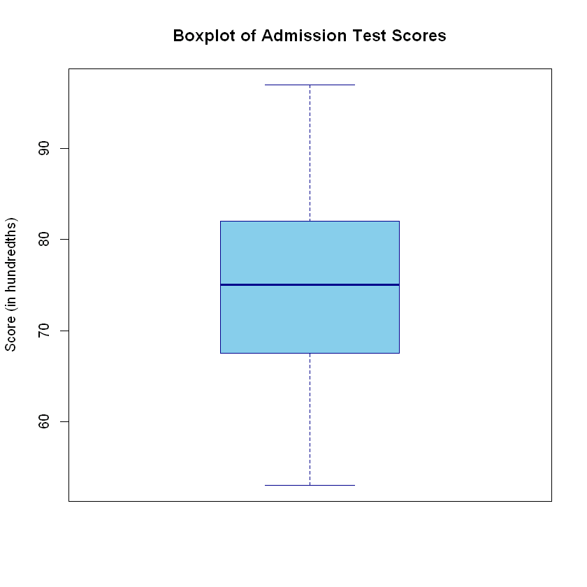

```python
votazioni <- c(
  68,84,75,82,68,90,62,88,76,93,
  73,79,88,73,60,93,71,59,85,75,
  61,65,75,87,74,62,95,78,63,72,
  66,78,82,75,94,77,69,74,68,60,
  96,78,89,61,75,95,60,79,83,71,
  79,62,67,97,78,85,76,65,71,75,
  65,80,73,57,88,78,62,76,53,74,
  86,67,73,81,72,63,76,75,85,77
)
boxplot(
  votazioni,
  main = "Boxplot of Admission Test Scores",
  ylab = "Score (in hundredths)",
  col = "skyblue",
  border = "darkblue"
)
summary(votazioni)
```

### A.4)

La distribuzione di frequenza assoluta degli stipendi mensili in euro dei 65 dipendenti di una determinata azienda è riportata nella seguente tabella:

| Stipendio | No. di dipendenti |
| --- | --- |
| 1000 ⊣ 1100 | 8 |
| 1100 ⊣ 1200 | 10 |
| 1200 ⊣ 1300 | 16 |
| 1300 ⊣ 1400 | 14 |
| 1400 ⊣ 1500 | 10 |
| 1500 ⊣ 1800 | 5 |
| 1800 ⊣ 2500 | 2 |
| Totale | 65 |

Si definisca la variabile Y , oggetto di interesse, e si dica se è qualitativa, sconnessa o ordinale, o quantitativa, discreta o continua. Con riferimento ai risultati della rilevazione, sintetizzati nella tabella di frequenza, si specifichi la associata distribuzione di frequenza relativa e le corrispondenti frequenze cumulate, assolute e relative. Si costruiscano le rappresentazioni grafiche mediante l’istogramma e il poligono di frequenza. Infine, si individui la classe mediana e, dopo aver fatto convenienti assunzioni semplificative, si calcoli la media aritmetica e la varianza

#### Definizione variabile Y e proprietà:

La variabile è quantitativa continua

#### Tabella frequenze:

| Stipendio | f | F | p | P |
| --- | --- | --- | --- | --- |
| 1000 ⊣ 1100 | 8 | 0,123 | 8 | 0,123 |
| 1100 ⊣ 1200 | 10 | 0,154 | 18 | 0,277 |
| 1200 ⊣ 1300 | 16 | 0,246 | 34 | 0,523 |
| 1300 ⊣ 1400 | 14 | 0,215 | 48 | 0,738 |
| 1400 ⊣ 1500 | 10 | 0,154 | 58 | 0,892 |
| 1500 ⊣ 1800 | 5 | 0,077 | 63 | 0,969 |
| 1800 ⊣ 2500 | 2 | 0,031 | 65 | 1 |
| Totale | 65 | 1 | 65 | 1 |

#### Istogramma e poligono di frequenza:

Per generare un istogramma, dobbiamo tenere conto dell'area di ciascun rettangolo, per convenzione: 100 = 1u

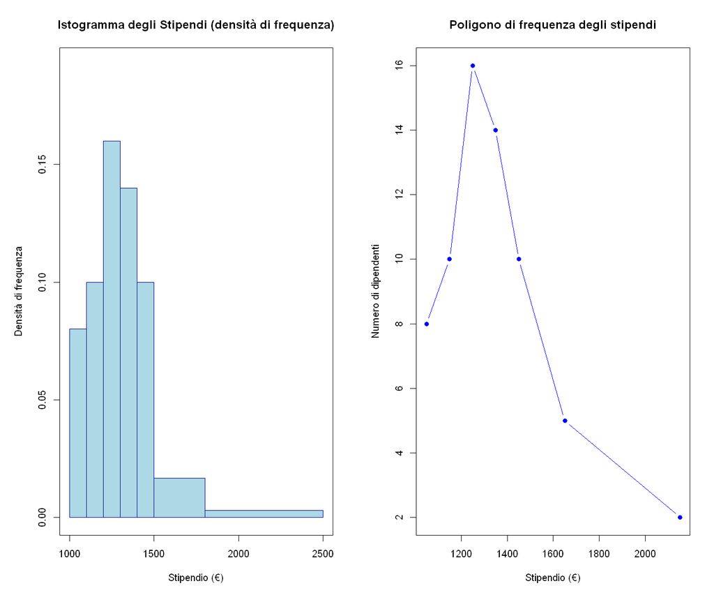

```python
# Absolute frequencies (number of employees)
freq <- c(8, 10, 16, 14, 10, 5, 2)
par(mfrow = c(1, 2), mar = c(5, 5, 4, 2))
options(repr.plot.width = 12, repr.plot.height = 10)

# Class intervals (for labels)
classes <- c("1000–1100", "1100–1200", "1200–1300",
             "1300–1400", "1400–1500", "1500–1800", "1800–2500")

# Midpoints of each class (used for the frequency polygon)
midpoints <- c(1050, 1150, 1250, 1350, 1450, 1650, 2150)

# Class widths
width <- c(100, 100, 100, 100, 100, 300, 700)

# Frequency densities
density <- freq / width

# Left limits of classes
left <- c(1000, 1100, 1200, 1300, 1400, 1500, 1800)

# Plot histogram manually
plot(NULL, xlim = c(1000, 2500), ylim = c(0, max(density) * 1.2),
     main = "Istogramma degli Stipendi (densità di frequenza)",
     xlab = "Stipendio (€)", ylab = "Densità di frequenza")

# Draw rectangles
for (i in 1:length(freq)) {
  rect(left[i], 0, left[i] + width[i], density[i],
       col = "lightblue", border = "darkblue")
}
plot(midpoints, freq, type = "b", pch = 19, col = "blue",
     main = "Poligono di frequenza degli stipendi",
     xlab = "Stipendio (€)", ylab = "Numero di dipendenti")
```

#### Classe mediana, media aritmetica e varianza:

Per trovare la classe mediana, bisogna individuare la classe in cui per la prima volta si supera 0.5, in questo caso: **1200 ⊣ 1300**  
Per trovare la **media aritmetica** dobbiamo usare la formula:

\( E(Y)=\sum^{J}_{j=1}y^c_jp_j \)

Sostuituendo con i numeri: \(E(Y)=1050\cdot0,123+1150\cdot0,154+1250\cdot0,246+1350\cdot0,215+1450\cdot0,154+1650\cdot0,077+2150\cdot0,031=1322\)

Per ottenere la **varianza** usuamo la seguente formula:

\( V(Y)=E[(Y-E(Y))^2] \)

Sostituendo i valori:

\( [0.1231\cdot(1050-1322)^2]+[0.1538\cdot(1150-1322)^2]+[0.2462\cdot(1250-1322)^2]+\)

\([0.2154\cdot(1350-1322)^2]+[0.1538\cdot(1450-1322)^2]+[0.0769\cdot(1650-1322)^2]+[0.0308\cdot(2150-1322)^2]≈46,989 \)

### A.5)

Su 15 studenti iscritti al secondo anno presso la Facoltà di Lettere e Filosofi a dell’Università di Udine si sono rilevate le seguenti variabili: provincia di residenza (con modalità, UD=Udine, AL=altro), corso di laurea (con modalità, C=Conservazione dei beni culturali, L=Lettere, D=DAMS) e grado di soddisfazione (con modalità, 1=insoddisfatto, 2=poco soddisfatto, 3=soddisfatto, 4=molto soddisfatto). I risultati della rilevazione sono riportati nella seguente matrice dei dati

| Studente | Provincia | Corso | Soddisfazione |
| --- | --- | --- | --- |
| 1 | UD | C | 1 |
| 2 | UD | C | 1 |
| 3 | UD | L | 2 |
| 4 | AL | D | 3 |
| 5 | AL | D | 3 |
| 6 | AL | L | 2 |
| 7 | UD | L | 4 |
| 8 | UD | D | 4 |
| 9 | UD | C | 4 |
| 10 | AL | C | 3 |
| 11 | AL | C | 3 |
| 12 | UD | L | 4 |
| 13 | AL | D | 2 |
| 14 | AL | C | 1 |
| 15 | AL | D | 3 |

Si individuino le variabili di interesse e si dica se sono qualitative, sconnesse o ordinali, o quantitative, discrete o continue. Con riferimento ai risultati della rilevazione, si specifichino le associate variabili statistiche, i loro supporti e le loro distribuzioni di frequenza assolute e relative. Si proponga una conveniente rappresentazione grafica per le tre serie statistiche e si determinino, ove hanno significato, le frequenze cumulate, assolute e relative. Infine, con riferimento alle tre variabili statistiche, si costruiscano degli opportuni indici di posizione.

### A.20)

Nella tabella di contingenza presentata di seguito si considerano i dati relativi al disastro del Titanic, suddividendo i passeggeri in base al Genere e al loro Status (morto o sopravvissuto)

|  | Genere | Genere |
| --- | --- | --- |
| Status | M | F |
| morto | 1364 | 126 |
| sopravvissuto | 367 | 344 |

Si determinino le distribuzioni di frequenza assoluta marginali per le due variabili. Si ottengano le corrispondenti frequenze relative congiunte e marginali e si definiscano le distribuzioni di frequenza relativa condizionata della variabile Status, rispetto ai valori della variabile Genere. Si calcoli l’indice di connessione χ2 e la sua versione normalizzata e si dia una valutazione sul livello di dipendenza tra le due variabili.

#### Distribuzioni di frequenza assoluta marginali

[output not shown]

[output not shown]

#### Indice di connessione χ2, versione normalizzata e valutazione:

\( x^2=\sum_{i,j}^{}\frac{(f_{ij}-f^{att}_{ij})^2}{f^{att}_{ij}}\)

\( f_{att}=\frac{totale-riga_i}{totale-colonna_j}\)

| Status | M | F |
| --- | --- | --- |
| Morto | (1490×1731)/2201 = **1171.1** | (1490×470)/2201 = **318.9** |
| Sopravvissuto | (711×1731)/2201 = **559.9** | (711×470)/2201 = **151.1** |

Per normalizzare:

\(x_{norm}^2=\frac{x^2}{n}\)

## B) Calcolo delle probabilità

### B.1)

Si considerino dieci urne, identiche in apparenza, di cui nove contengono due palline bianche e due nere ciascuna e una contiene cinque palline bianche e una nera. Scelta a caso un’urna, si estrae una pallina che risulta essere bianca. Quale è la probabilità che la pallina sia stata estratta dall’urna contenente cinque palline bianche?

urine tot = 10  
9 urne = 2b 2n $\rightarrow p=\frac12$  
1 urna = 5b 1n $\rightarrow p=\frac56$

**Applichiamo Bayes:**  
$P(spec|bianca)=P(bianca|spec)\cdot \frac{P(spec)}{P(bianca|spec)P(spec)+P(bianca|reg)P(reg)}$  
**Sostituendo:**  
$P(spec|bianca)=\frac56 \cdot \frac{\frac 1{10}}{\frac56 \cdot \frac1{10} + \frac12 \cdot \frac9{10}}=\frac 5{32}=0.156$

### B.2)

Si supponga di sapere che una porzione pari a 0.001 di una certa popolazione è affetto da una determinata malattia. Per rilevare tale patologia si utilizza un test diagnostico con le seguenti caratteristiche: se una persona è ammalata, il test risulta positivo con probabilità 0.999, mentre, se è sana il test risulta positivo con probabilità 0.002. Scelta a caso una persona, se il test risulta positivo, quale è la probabilità che la persona sia veramente affetta dalla malattia?

P(M)=0.001  
P(!M) = 1 - 0.001= 0.999  
Falso positivo= 0.002

**Bayas:**
$$P(M|T^+)=P(T^+|M)\cdot \frac{P(M)}{P(T^+|M)P(M)+P(T^+|!M)P(!M)}$$

**Sostituendo:**

$$ P(M|T^+)=0.999 \cdot \frac{0.001}{0.999 \cdot 0.001 + 0.002 \cdot 0.999}=0.333$$

### B.3)

Si consideri un’urna contenente 10 palline, delle quali 5 sono nere. Si lanci un dado regolare e quindi si estragga dall’urna un campione, senza reinserimento, di ampiezza pari al numero che risulta dal lancio del dado. Determinare la probabilità che tutte le palline del campione siano nere.

P(tutte nere|K)= $\frac{\binom5k}{\binom{10}k}$
**prob fin:**
$$P=\sum^{6}_{k=1}P(dado=k)P(tutte-nere|k)$$

**calcoli:**

$P=\frac16 \cdot(\frac12 + \frac29 + \frac 1{12} + \frac1{42}+ \frac1{242})=0.139$

### B.4)

Nel gioco del Superenalotto vengono estratti, senza reinserimento, da un’urna contenente i numeri da 1 a 90 sei numeri e un settimo numero detto numero jolly. Si totalizza 6, se si indovinano i sei numeri estratti; si totalizza 5+1, se si indovinano 5 dei 6 numeri estratti e il numero jolly. Quale è la probabilità di totalizzare 6 scommettendo su sei numeri? Quale è la probabilità di totalizzare 6 o 5 + 1 scommettendo su sei numeri? Quale è la probabilità di totalizzare 6 scommettendo su dieci numeri?

**Calcolo sesitne possibili:**  
$\binom{90}{6}=622614630$  
**Prob di 6:**  
$P(6)=\frac1{\binom{90}6}$  
**Prob 5+1**  
$\frac{\binom{6}{5}\binom{84}{1}}{\binom {90}6}=\frac{6 \cdot 84}{\binom {90}{6}}$ prob che il jolly sia il 6° numero: $\frac1{84}$

$P(5+1)=\frac{6 \cdot 84}{\binom {90}6}\cdot \frac1{84}=\frac6{\binom{90}6}$

#### Probabilità di totalizzare 6 giocando 10 numeri:

$P(6con10numeri)=\frac{\binom{10}{6}}{\binom {90}{6}}=\frac{21}{62261463}$

### B.5)

Una compagnia di assicurazione suddivide gli assicurati in persone propense e non propense agli incidenti. è noto che le persone propense agli incidenti hanno una probabilità pari a 0.2 di riportare incidenti in un anno, mentre questa probabilità scende a 0.05 per le altre persone. Se il 30% della popolazione è propensa agli incidenti, quale è la probabilità che un nuovo assicurato abbia un incidente nel primo anno? Se il nuovo assicurato ha effettivamente avuto un incidente nel primo anno, quale è la probabilità che sia propenso agli incidenti?

**Popolazione:**  
P(P)=0.30 (propensa)  
P(N)=0.70 (non propensa)  
**Probabilità incidente:**  
$P(I|P)=0.20$  
$P(I|N)=0.05$

**Prob totale:**  
$P(I)=P(I|P)P(P)+P(I|N)P(N)$  
$P(I)=0.20 \cdot 0.30 + 0.05 \cdot 0.70= 0.095$

#### Probabilità nuovo assicurato ha effettivamente avuto un incidente nel primo anno

$P(P|I)=P(I|P)\frac{P(P)}{P(I)}$  
**Sostituendo:**  
$P(P|I)=\frac{0.20 \cdot 0.30}{0.095}=0.6316$

### B.6)

Un’industria alimentare si è dotata di un sistema automatico per il controllo della qualità. Tale sistema scarta un elemento non conforme con probabilità 0.9 e scarta erroneamente un elemento conforme con probabilità 0.01. Dall’analisi dei dati storici è noto che la proporzione di elementi non conformi prodotti dall’azienda è pari a 0.001. Se un elemento viene scartato dal sistema, quale è la probabilità che sia eff ettivamente non conforme?

P(NC)=0.001  
P(C)=0.999

P(S|NC)=0.9  
P(S|C)=0.01

$P(NC|S)=P(S|NC)\frac{P(NC)}{P(S|NC)P(NC)+P(S|C)P(C)}$  
**Sostituendo:**  
$P(NC|S)=0.9 \frac{0.001}{0.9 \cdot 0.001 + 0.01 \cdot 0.999}= 0.0826$

### B.7)

Un gioco a premi televisivo è costituito da domande a risposta multipla. Con riferimento ad una singola domanda, sono previste 6 possibili risposte. Un concorrente decide di rispondere a caso se non conosce la risposta esatta. Sia 0.7 la probabilità che il concorrente conosca la risposta esatta alla singola domanda. Quale è la probabilità che il concorrente risponda esattamente ad una singola domanda? Se risponde correttamente alla domanda, quale è la probabilità che sia stato a conoscenza della risposta? Nell’ipotesi che il concorrente non modifi chi la propria strategia di gioco, quale è la probabilità che su due domande risponda esattamente ad almeno una di esse?

Poss:6  
P(C)=0.7  
P(!C)=0.3

**Prob singola domanda:**  
$P(P(C)|P(I))= 1 \cdot 0.7 + \frac16 \cdot 0.3=0.75$

**Prob sapesse la domanda:** $P(C|corretta)=P(correta|K)\frac{P(K)}{P(corretta)}=1\frac{0.7}{0.75}=0.933$

**Prob risponda almeno una su sue:**  
P(almeno una corretta)=1-P(nessuna corretta)=1-(1-p$^2$)=1-(0.25)$^2$=0.9375

### B.8)

Si considerano due urne. La prima contiene 3 palline nere e 7 bianche, mentre la seconda contiene 3 palline nere e 3 bianche. Si estrae una pallina dalla prima urna e, senza vederla, la si inserisce nella seconda. Successivamente si estrae dalla seconda urna una pallina. Quale è la probabilità che la pallina estratta dalla seconda urna sia bianca? Se la pallina estratta dalla seconda urna risulta essere bianca, quale è la probabilià che anche la pallina estratta dalla prima urna sia stata bianca?

U1= 3b 7n  
U2= 3b 3n  
$P(B_1)=\frac7{10}$  
$P(N_1)=\frac3{10}$  
**caso pallina bianca:** $P(B_2|B_1)=\frac47$  
**caso pallina nera:** $P(B_2|N_1)=\frac37$  
**prob tot:**  
$P(B_2)=P(B_2|B_1)P(B_1)+P(B1)+P(B_2|N_1)P(N_1)$  
$P(B_2)=\frac47 \cdot \frac7{10}+\frac37 \cdot \frac3 {10}=0.5286$

#### Seconda parte:

$P(B_1|B_2)=P(B_2|B_1)\frac{P(B_1)}{P(B_2)}=\frac{\binom{4}{7}\binom{7}{10}}{\frac{37}{70}}=\frac{28}{37}=0.7568$

### B.9)

Un sistema telegrafico trasmette linee e punti. è noto che 2/5 dei punti e 1/3 delle linee viene deformato durante la trasmissione. Inoltre, la probabilità che il sistema telegrafico trasmetta un punto è 5/8, mentre la probabilità che trasmetta una linea è 3/8. Si determini la probabilità che il segnale ricevuto sia uguale a quello trasmesso se il segnale ricevuto è un punto e se il segnale ricevuto è una linea.

$P(P)=\frac58$  
$P(L)=\frac38$

prob punto def: $\frac25$  
prob linea def: $\frac13$

#### Primo caso:

$P(Trasmesso=P|Ricevuto=P)$  
$P(P\rightarrow P)=P(P)\cdot \frac35=\frac58 \cdot \frac35=\frac38$  
$P(L\rightarrow P)=P(L)\cdot \frac13=\frac38 \cdot \frac13=\frac18$

**Sommando:**  
$P(R=P)=\frac38+\frac18=\frac12$

**Bayes:**

$P(P|R=P)=\frac{P(P\rightarrow P)}{P(R=P)}=\frac{3/8}{1/2}=\frac34$

#### Secondo caso:

$P(trasemsso=L|ricevuto=L)$  
$P(L \rightarrow L)=P(L)\cdot \frac{2}{3}=\frac38 \cdot \frac23=\frac{1}{4}$  
$P(P \rightarrow L)=P(P)\cdot \frac25=\frac58 \cdot \frac25=\frac14$  
**Sommando:**  
$\frac14 + \frac14 = \frac12$  
**Bayes:**  
$P(L|R=L)=\frac{P(L \rightarrow L)}{P(R=L)}=\frac{1/4}{1/2}=\frac12$

### B.10)

Un’urna contiene dieci palline, tre nere e sette bianche. Ogni volta che si estrae una pallina dall’urna, viene reinserita con un’altra dello stesso colore. Quale è la probabilità di osservare pallina nera in tre estrazioni successive? Se alla seconda estrazione si è osservato pallina nera, quale è la probabilità che anche alla prima estrazione sia uscita pallina nera?

$P(B)=7$  
$P(N)=3$

**prob 3 in fila:**  
$\frac{3}{10} \cdot \frac{4}{11} \cdot \frac{5}{12} = \frac{60}{1320}=0.045$

#### Se alla seconda estrazione si è osservato pallina nera:

$P(B_1|B_2)=\frac{P(B_1 \cap B_2)}{P(B_2)}$  
$P(B_1 | B_2)= \frac{\frac{3}{10} \cdot \frac{4}{11}}{\frac{3}{10}}=0.363$

### B.11)

Una popolazione presenta il 32% di fumatori. è noto che il 25% dei fumatori e il 5% dei non fumatori è affetto da una patologia respiratoria cronica. Quale è la probabilità che un individuo scelto a caso da questa popolazione sia affetto dalla malattia? Quale è la probabilità che una persona scelta a caso da questa popolazione, e risultata affetta dalla malattia respiratoria, sia un fumatore?

$P(F)=0.32$  
$P(S)=0.68$  
$P(A|F)=0.25$  
$P(A|S)=0.05$

**prob persona affetta:**  
$P(A)=P(F)\cdot P(A|F) + P(S)\cdot P(A|S)$  
$P(A)=0.32 \cdot 0.25 + 0.68 \cdot 0.05 = 0.114$

#### Persona scelta a caso:

$P(F|A)=P(A|F)\frac{P(F)}{P(M)}=0.25\frac{0.32}{0.114}=0.702$

### B.12)

Un fornitore di componenti elettronici raccoglie la sua produzione in tre classi, A, B, C, che contengono rispettivamente il 3%, il 9% e il 13% di pezzi difettosi. Le tre classi, inoltre, coprono rispettivamente il 15%, il 35% e il 50% della sua produzione. Avendo scelto un lotto di componenti, senza sapere a quale classe appartenga, e avendo riscontrato che un pezzo estratto a caso dal lotto è risultato difettoso, quale è la probabilità che il lotto in esame sia di classe C?

| $P(A)= 15\%$ | $P(D \textbar A)=3\%$ |
| --- | --- |
| $P(B)=35\%$ | $P(D\textbar B)=9\%$ |
| $P(C)=50\%$ | $P(D\textbar C)=13\%$ |

$P(D)=P(D∣A)P(A)+P(D∣B)P(B)+P(D∣C)P(C)$  
$P(D)=0.0045+0.0315+0.065=0.101$

$P(C|D)=P(D|C)\frac{P(C)}{P(D)}=0.13\frac{0.50}{0.101}=0.6436$

### B.13)

Si considerino 5 urne, identiche in apparenza, contenenti 4 palline nere e un numero variabile di palline bianche. In particolare, l’i-esima urna, i = 1, . . . , 5, contiene i + 2 palline bianche. Si sceglie a caso un’urna e si estrae una pallina. Si calcoli la probabilità che la pallina estratta sia bianca. Supponendo che l’estrazione abbia dato come risultato una pallina bianca, si individui da quale urna è più plausibile che sia stata effettuata l’estrazione.

A= 4n 3b  
B= 4n 4b  
C= 4n 5b  
D= 4n 6b  
E= 4n 7b

$\frac{1}{5}(\frac{3}{7}+\frac{4}{8}+\frac{5}{9}+\frac{6}{10}+\frac{7}{11})=0.544$ (prob estrarre pallina bianca)  
La più probabile è l'urna E

### B.14)

Uno studio sull’efficacia di un test diagnostico per l’anemia da carenza di ferro ha dato i seguenti risultati:

|  | Anemia | Anemia |  |
| --- | --- | --- | --- |
| Test | Si | No | Totale |
| positivo | 187 | 5 | 192 |
| negativo | 7 | 340 | 347 |
| totale | 194 | 345 | 539 |

Sulla base di tali dati si stimi la probabilità che il test sia positivo se l’individuo è ammalato e la probabilità che il test sia negativo se l’individuo è sano. Se la probabilità che un individuo, scelto a caso dalla popolazione, sia affetto dalla patologia è 0.005, si calcoli la probabilità che l’individuo sia ammalato se il test è risultato positivo.

Ammalati tot: 194  
Test positivo tra ammalati: 187  
$P(T^+|A)=\frac{187}{195}=0.964$  
$P(T^-|S)=\frac{340}{345}=0.986$

#### prob una persona sia ammalata se il test è positivo:

| $P(A)=0.005$ | $P(S)=1-0.005=0.995$ |
| --- | --- |

**prob test positivo:**  
$P(T^+)=P(T^+|A)P(A)+P(T^+|S)P(S)$  
$P(T^+)=0.964 \cdot 0.005 + 0.014 \cdot 0.995= 0.01875$

**Bayes:**  
$P(A|T^+)=P(T^+|A)\frac{P(A)}{P(T^+)}$  
$P(A|T^+)=0.964\frac{0.005}{0.01875}=0.257$

### B.15)

Una donna, sofferente di diabete mellito, insulino dipendente, alla 17a settimana di gravidanza, è risultata positiva al test per l’alfa-proteina nel siero materno. La probabilità che il test sia positivo, se il feto risulta ammalato, e la probabilità che il test sia negativo, se il feto risulta sano, corrispondono a 0.34 e 0.86, rispettivamente. Se dalla letteratura medica si deduce che, in generale, c’è una probabilità pari a 0.20 che il feto sia ammalato, si calcoli la probabilità che ci sia la patologia se il test è risultato positivo.

$P(T^+|A)=0.34$  
$P(T^-|S)=0.86$  
$P(A)=0.20$

$P(T^+)=P(T^+∣A)P(A)+P(T^+∣S)P(S)=0.18$

#### Probabilità che il feto sia ammalato dato test positivo:

$P(A|T^+)=P(T^+|A)\frac{P(A)}{P(T^+)}$  
$P(A|T^+)=0.34\frac{0.20}{0.18}=0.378$

### B.16)

Si consideri la funzione:

\(\begin{cases} 0 & x < −\frac{1}{2} \\ \frac{1}{2}+ 2x + 2x^2 & −\frac{1}{2} ≤ x < 0 \\ \frac{1}{2} + 2x − 2x^2 & 0 ≤ x < \frac{1}{2}\\ 1 & x ≥ \frac{1}{2} \end{cases}\)

Si verifichi che F(x) è la funzione di ripartizione di una variabile casuale X continua e si ottenga la funzione di densità di probabilità. Si calcoli P(|X| ≤ 1/4), P(X = 0) e P(|X| ≤ 1/4|X ≥ 0). Si determini il valore atteso, la moda, la mediana e la varianza di X.

#### Creazione grafico e analisi:

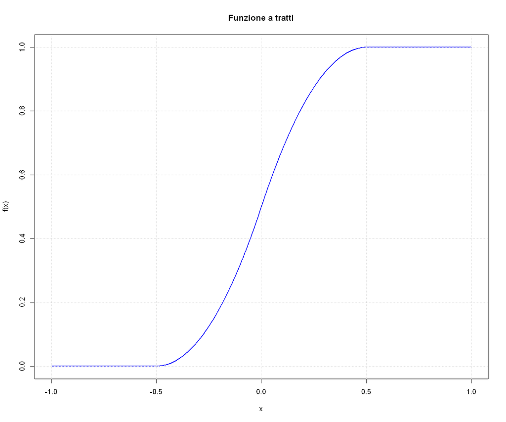

```python
plot(x, y, type = "l", col = "blue", lwd = 2,
     xlab = "x", ylab = "f(x)",
     main = "Funzione a tratti")
grid()
```

#### Funzione di densità

**Non negatività:**  
per tutti i valori inseriti all'interno della funzione non si presentano valori negativi  
$P(|X|\leq \frac14)=F(\frac14)-F(-\frac14)$  
$F(\frac14)=\frac12+2\cdot\frac14-2\cdot(\frac14)^2=\frac78$  
$F(-\frac14)=\frac12+2\cdot(-\frac14)+2\cdot(-\frac14)^2=\frac18$  
$\implies P(|X|\leq\frac14)=\frac78-\frac18=\frac34$

**P(X=0):**  
$P(X=0)=F(0)-F(0^-)=\frac12-\frac12=0$

#### Valore atteso, moda, mediana e varianza di X:

**Valore atteso:**
$$E[X]=\int^{0}_{-1/2}x(2+4x)dx+\int^{1/2}_{0}x(2-4x)dx$$ $E[X]=0$
Media=0
**Mediana:**
Mediana=0
**Moda:**
Moda=0
**Varianza:**
$$E[X^2]=\int^{0}_{-1/2}x^2(2+4x)dx+\int^{1/2}_{0}x^2(2-4x)dx$$
$E[X^2]=\frac1{24}=0.0417$
visto che $E[X]=0\implies Var(X)=E[X^2]-(E[X])^2=0.0417$

### B.17)

Una rete è costituita da 15 PC per altrettanti operatori e da un server che permette la connessione di al più 10 PC. In un dato istante, ogni operatore richiede la connessione al server con probabilità p = 0.5. Ogni utente opera in modo indipendente. Quale è la probabilità che, ad un dato istante, la rete sia satura? Quale è il numero medio di operatori che, in un dato istante, si connettono al server?

#### Risoluzione:

$$Pr(X\geq 10)=\sum^{15}_{k=10}\frac{\binom{15}k}{2^{15}}=\frac{4944}{32768}=0.151$$
**Prob server saturo:** 15%
**Numero di operatori medio**
$E[X]=np=15\cdot 0.5=7.5$

### B.18)

Si consideri la funzione:

\(\begin{cases} a^{bx} & x < 0 \\ 1 & x ≥0 \\ \end{cases}\)

con a ∈ [0, 1] e b > 0 opportuni numeri reali. Si dica se F(x) è una funzione di ripartizione. Inoltre, si determini per quali valori di a e b F(x) è una funzione di ripartizione di una variabile casuale continua. In questo caso, si calcoli la funzione di densità.

#### Variabile continua e densità:

**per x <0:**
$f(x)=\frac{d}{dx}a^{bx}=b\cdot ln(a)a^{bx}$
**per x ≥ 0:**
$f(x)=0$
**verifica normalizzazione:**
$$\int^{+\infty}_{-\infty}f(x)dx=\int^0_{-\infty}b\cdot ln(a)dx=[a^{bx}]^{x=0}_{x=-\infty}=1-0=1$$

### B.19)

Sia X una variabile casuale con supporto $S_X$ = [2, +∞) e funzione di densità $f_X (x) = kx^{−2}$, se x ∈ $S_X$, e nulla altrove, con k l’opportuna costante di normalizzazione. Si determini la costante k. Si calcoli il valore atteso, la moda, la mediana e la varianza di X.

**Calcolo costante normalizzazione k:**
$$\int^{\infty}_{2}x^{-2}dx=[-\frac1x]^{\infty}_2=0-(-\frac12)=\frac12$$
$k\cdot \frac12 =1 \implies k=2$
quindi $f(x)=2x^{-2}$ se $x \geq 2$

### B.20)

Sia X una variabile casuale con supporto \(S_X\) = [−1, +∞) e funzione di densità \(f_X (x) = ke^{−x}\) , se x ∈ \(S_X\) , e nulla altrove, con k l’opportuna costante di normalizzazione. Si determini la costante k. Si calcoli il valore atteso, la moda e la mediana di X.

#### Risoluzione:

\( S_X[-1,+\infty] \)  
\( f(x)=ke^{-x} \hspace{1cm}se\hspace{0.2cm}X\in S(x) \)

\( f(x)= \begin{cases} ke^{-x} & x ≥ -1 \\ 0 & x <-1 \\ \end{cases}\)

\( \int_{-1}^{+\infty}ke^x=1\longrightarrow\int_{-1}^{+\infty}e^x=0-e=+e \)

\( k \cdot e = 1 \longrightarrow k = \frac{1}{e} \)

\( F(x)= \int_{-1}^{x}e^{-(t+1)}=1-e^{-(x+1)} \)

### B.21)

Su mille automobili vendute di un certo modello, ogni mese 10 richiedono un intervento di assistenza. Un concessionario ha venduto 100 automobili di questo tipo. Si proponga un modello probabilistico ragionevole per la variabile casuale X che conta il numero di interventi di assistenza (alle 100 automobili vendute) che tale concessionario effettuerà nel prossimo mese. Si calcolino E(X), V (X) e P(X = 0).

1% grande  
$x \sim lineare $ 100  
E(x)=1  
V(x)=0,99  
P(x=0) $100\cdot(0.001)^0 \cdot (0.99)^{100}=0,366$

### B.22)

Sia X la variabile casuale che conta il numero di volte con cui esce un numero maggiore o uguale a 5, lanciando tre volte un dado. Nell’ipotesi che il dado sia regolare, si determini il supporto, la funzione di probabilità e la funzione di ripartizione di X. Inoltre, si calcoli il valore atteso, la moda, la mediana e la varianza di X.

$\frac{2}{6} =\frac{1}{3}$  
$x \sim lineare \binom{3}{0} \frac{1}{3}$  
$S={0,1,2,3}$  
$E(x)=1$  
$V(x)= \frac{2}{3}$  
$P(x=0)= \binom{3}{0} \cdot (\frac{1}{3}^0 \cdot (\frac{2}{3})^3)=0.296$  
$P(x=1)= \binom{3}{1} \cdot (\frac{1}{3}^1 \cdot (\frac{2}{3})^3)=0.44$  
$mediana = 1$  
$moda = 1$  
$V(x)=3\cdot \frac{1}{3}\cdot\frac{2}{3}=\frac{2}{3}$

#### Risoluzione

I lanci possibili del dado sono N=3

Per ogni lancio la probabilità di successo: P= 1/3

\( X=(circa) B_i(3_i,\frac{1}{3})\)

\( f_x(x)= \begin{cases} \binom3x\frac{1}{x}^x(2-\frac{1}{3}) & x ∈ S_x \\ 0 & x ≠ S_x \\ \end{cases} \)

\( \begin{cases} 0 & x < 0\\ 0,296 & 0 <= x < 2 \\ 0,74 & 1 <= x < 2 \\ 0,96 & 2<=x<3 \\ 1 & x>=3 \end{cases} \)

\(f_x()= \begin{cases} (\frac{2}{3})^{x-1} & x =1,2,3,...\\ 0 & ------\\ \end{cases} \)

### B.23)

Sia X la variabile casuale che conta il numero di lanci di un dado affinchè esca per la prima volta un numero maggiore o uguale a 5. Nell’ipotesi che il dado sia regolare, si proponga un modello probabilistico ragionevole per la variabile casuale X. Inoltre, si calcoli il valore atteso e la varianza di X.

$p=Pr(numero≥5)=\frac26=\frac13$  
$X\sim Geom(p=1/3)$  
$Pr(X=k)=p(1-p)^{k-1}$  
$Pr(X=k)=\frac13(\frac23)^{k-1}$

**Valore atteso:**  
$E[X]=\frac1p=\frac1{1/3}=3$  
**Varianza:**  
$Var(X)=\frac{1-p}{p^2}$  
$\implies Var(X)=\frac{2/3}{(1/3)^2}=\frac{2/3}{1/9}=6$

### B.24)

Un test di ingresso è costituito da 4 domande a risposta multipla, ognuna delle quali ha 5 risposte possibili, con una sola corretta. Lo studente impreparato risponde casualmente ad ognuna delle domande. Si proponga un modello probabilistico ragionevole per la variabile casuale X che conta il numero di risposte positive alle 4 domande da parte dello studente. Si calcolino E(X), V (X), P(X = 3) e P(X = 0).

$P=\frac15=0.2$
X= numero risposte positive su 4
$X\sim Bin(n=4,p=1/5)$
il supporto: $S_X=\{0,1,2,3,4\}$
$$P(K=k)=\binom4kp^k(1-p)^{4-k}=\binom4k(\frac15)^k(\frac45)^{4-k}$$ **Valore Atteso:**
$E[X]=np = E(X)=4\cdot\frac15=0.8$
**Varianza:**
$Var(X)=np(1-p)$
$Var(X)=4\cdot \frac15 \cdot \frac 45=0.64$

**P(X=0)**  
$P(X=0)=\binom40 (\frac15)^0 (\frac45)^4=0.4096$

### B.25)

In una piccola concessionaria di automobili si presenta mediamente un cliente ogni 4 ore. Si proponga un modello probabilistico ragionevole per la variabile casuale X che conta il numero di clienti che si presentano in un ora. Si calcoli la probabilità che in un’ora entri esattamente una persona e che in un’ora entri almeno una persona.

#### Calcoli

\( X~P(λ) λ=\frac{1}{4} \)

\( f_x(x) \begin{cases} \frac{(\frac{1}{4})^{x}e^{-\frac{1}{4}}}{x!} & x =0,4\\ 0 & ------\\ \end{cases} \)

\( P(X≥1)=1-P(X=0)=1-e^{-\frac{1}{4}}=0,221 \)

### B.26)

Il tempo che mediamente trascorre tra l’apertura di uno sportello pubblico e l’arrivo del primo utente è di 4 minuti. Si proponga un modello probabilistico ragionevole per la variabile casuale X che descrive il tempo tra l’apertura dello sportello e l’arrivo del primo utente. Si determini la probabilità che il tempo d’attesa del primo utente superi i 5 minuti. Infine, si calcolino i quartili di X

#### modello probabilistico:

$λ=\frac1{E[X]}=\frac14$ (per minuto)

#### Tempo di attesa sup 5 min:

$P(X>5)=1-F_X(5)=e^{-λ\cdot 5}=e^{-5/4}=e^{-1.25}=0.2865$

#### Quartili di X

$F_X(q_p)=p \implies q_p=-\frac1λln(1-p)$  
**primo quantile:**  
$P=0.25 \implies 4\cdot ln (\frac1{1-0.25})=4ln(\frac43)=1.1507 min$  
**secondo quantile:**  
$P=0.5 \implies 4\cdot ln(2)=2.7726 min$  
**terzo quantile:**  
$P=0.75 \implies 4\cdot ln(4)= 5.5452 min$

### B.27)

Un’azienda fabbrica termometri che si suppongono in grado di fornire la lettura di 0°C al punto di congelamento dell’acqua. In realtà, la lettura che forniscono è descritta da una variabile casuale X ∼ N(0.05, 1.1). Scelto a caso un termometro, determinare la probabilità che, al punto di congelamento dell’acqua, la lettura sia meno di 1.58 ° C, sia almeno −1.23 ° C e sia compresa tra −2.00 ° C e 1.50 ° C. Infine, si determinino i valori di temperatura che delimitano il 2.5% inferiore e il 2.5% superiore della distribuzione di probabilità si X.

$Z=\frac{X-μ}σ$

#### Probabilità meno di 1.58:

\( P(X<=1,58)=P\frac{z-0.05}{\sqrt{1.1}}<=\frac{1,58-0,05}{1,05}=0,927 \)

#### Valori di temperatura che delimitano il 2.5% inferiore e il 2.5% superiore della distribuzione di probabilità si X

\( P(X_ax)=0,025 \)

\(P(\frac{X-0,05}{1,05}≥\frac{x-0,05}{1,05}) \)

\( \frac{x-0,05}{1,05}=1,96 \hspace{0,25cm} (trovare \hspace{0,25cm} x\hspace{0,25cm} per\hspace{0,25cm} il \hspace{0,25cm}2.5\% \hspace{0,25cm} inferiore) \)

### B.28)

La durata di un circuito integrato è descritta da una variabile casuale con distribuzione esponenziale con media pari 2 anni. Si determini la probabilità che il circuito duri più di 3 anni. Inoltre, nell’ipotesi che il circuito dopo 4 anni sia ancora funzionante, si calcolo la probabilità che funzioni per almeno altri 3 anni.

#### Risoluzione:

$λ=\frac{1}{T}=\frac{1}{2}$  
**Probabilità soppravvivenza:**  
$P(T>t)=e^{-λt}= e^{-\frac{1}{2}}$  
**probabilità durata > 3 anni:**  
$P(T>3)=e^{-\frac32} = 0,223$  
**Proprietà fondamentale: assenza di memoria:**  
$P(T>s+t∣T>s)=P(T>t)$: Il tempo già trascorso non influenza il tempo futuro di funzionamento.  
**Probabilità che funzioni per almeno altri 3 anni:**  
medesima del caso prima: 0,223

### B.29)

La variabile casuale X, che descrive il numero di difetti in un fi lo di rame di lunghezza 3 cm, ha la seguente distribuzione di probabilità:

| $x$ | 0 | 1 | 2 | 3 |
| --- | --- | --- | --- | --- |
| $P(X = x)$ | 0.48 | 0.39 | 0.12 | 0.01 |

Si considerano 100 fili di rame. Utilizzando una opportuna approssimazione, si determini la probabilità che il numero medio di difetti per filo, considerando i 100 fili in esame, sia minore di 0.5 e la probabilità che la somma totale dei difetti riscontrati nei 100 fili sia minore di 25.

#### risoluzione:

**Variabile casuale di base:**

| $x$ | 0 | 1 | 2 | 3 |
| --- | --- | --- | --- | --- |
| $P(X = x)$ | 0.48 | 0.39 | 0.12 | 0.01 |

**Calcolo di media e varianza di 𝑋:**  
*Valore atteso:*  
$E[X]= \sum x \cdot P(X=x)= 0 \cdot 0.48 + 1 \cdot 0.39 + 2 \cdot 0.12 + 3 \cdot 0.01= 0.66$

*Secondo momento:*  
$E[X^2]=0^2 \cdot 0.48 + 1^2 \cdot 0.39 + 2^2 \cdot 0.12 + 3^2 \cdot 0.01= 0.96 $

*varianza:*  
$Var(X)= E[X^2]- (E[X])^2 = 0.96−(0.66)^2=0.96−0.4356=0.5244$  
$\sigma ^ 2 = 0.5244 \vee \sigma = 0.724$

**Numero medio di difetti nei 100 fili:**
$$\overline{\rm X}_{100}= \frac{1}{100} \sum^{100}_{i=1}X_i$$ $E[\overline{\rm X}_{100}]=μ=0.66$
$Var(\overline{\rm X}_{100}= \frac{\sigma ^ 2}{100}) \implies \sigma_{\overline{\rm X}}=\frac{0.724}{\sqrt{100}}=0.0724$

**Approssimazione: Teorema del Limite Centrale:**  
$\overline{\rm X}_{100} \approx N(0.66, 0.0724^2)$

**Probabilità che il numero medio sia minore di 0.5:**  
$P(\overline{\rm X}_{100}) < 0.5)$  
$Z=\frac{0.5-0.66}{0.0724} \approx -2.21 \implies P(Z<−2.21) \approx 0.0136 \implies P(\overline{\rm X}_{100} < 0.5) \approx 0.014$

**Somma totale dei difetti nei 100 fili:**  
$S_{100}=\sum^{100}_{i=1}X_i$  
*Media e deviazione standard:*  
$E[S_{100}]=100 \cdot 0.66= 66$  
$\sigma ^ 2 = \sqrt{100} \cdot 0.724 = 7.24$

**Approssimazione normale della somma**  
$S_{100} \approx N(66, 7.24^2)$  
$P(S_{100} < 25)$  
*Standardizzazione:*  
$Z=\frac{25-66}{7.24} \approx -5.66$  
**Probabiltà finale**  
$P(Z<-5.66) \approx 0$

### B.30)

Il numero medio di connessioni ad un sito web segue una distribuzione di poisson con una media di 27 connessioni all’ora. Si determini la probabilità che avvengano più di 90 connessioni in tre ore.

#### Calcoli:

λ= 27 connessioni/ora  
$λ_{3h}=27 \cdot 3 = 81$  
$N \sim Poisson(81)$

**Approssimazione normale della Poisson:**  
$Poisson(λ) \approx N(\mu = \lambda, \sigma ^2 = \lambda) = N(81,81)$

**Correzione di continuità:**  
$P(N>90) \approx P(N \geq 91) \approx P(N>90.5)$

**Standardizzazione:**  
$Z=\frac{90.5 - 81}{9}=\frac{9.5}{9} \approx 1.06$

**Calcolo probabilità:**  
$P(Z<1.06) \approx 0.855 \implies P(Z>1.06)=1-0.855 = 0.145$

### B.31)

Nella fase di progettazione dei sedili di un aereo commerciale si vuole considerare una larghezza tale da soddisfare la quasi totalità dei potenziali utilizzatori maschi. Tenendo conto del fatto che la larghezza in cm dei fianchi degli uomini è descritta da una variabile casuale X ∼ N(36.5, 6.25), si determini l’ampiezza dei sedili che li rende accessibili al 95% degli uomini.

#### Calcoli:

$X\sim N(36.5, 6.25) \implies \mu = 36.5cm, \sigma ^2 = 6.25, \sigma = \sqrt{6.25}=2.5cm$

$P(X \leq w)= 0.95$

**Standardizzazione:**  
$Z=\frac{X- \mu}{\sigma} \sim N(0,1) \implies P(Z \leq \frac{w- 36.5}{2.5})=0.95$

**Quantile della normale standard:**  
$P(Z \leq z_{0.95})=0.95 \implies z_{0.95}=1.645$

**Calcolo della larghezza del sedile:**  
$\frac{w-36.5}{2.5}=1.645 \implies w= 36.5 +1.645 \cdot 2.5 \approx 40.6cm$

### B.32)

è noto che il 5% dei semi di frumento di una determinata partita non germoglierà. I semi vengono venduti in confezioni da 200 semi, dei quali viene garantita la germinazione per almeno il 90%. Utilizzando una opportuna approssimazione, si determini la probabilità che una confezione non sia conforme a tale garanzia.

#### Calcoli:

$p=0.95$  
$0.9 \cdot 200 = 180$

**modello probabilistico:**  
$X \sim Binomiale(n=200, p=0.95) \implies P(X<180)$  
$\mu = np = 200\cdot 0.95 = 190$  
$\sigma ^ 2 = np(1-p)=200\cdot 0.95 \cdot 0.05 =9.5 \implies \sigma = \sqrt{9.5} \approx 3.08$

**approssimazione normale:**  
$X \approx N(190,9.5)$

**Corelazione di continuità**  
$P(X<180)=P(X\leq 179) \implies P(X \leq 179) \approx P(X < 179.5)$

**standardizzazione:**  
$Z=\frac{179.5-190}{3.08} \approx -3.41$

**calcolo probabilità:**  
$ P(Z<-3.14) \approx 0.0003 \implies 0.03 \%$

### B.33)

Sia $\{X_n \}_n \leq 1$ una successione di variabili casuali con distribuzione di probabilità poisson di parametro nλ, con λ > 0. Si studi la convergenza in probabilità della successione $\{Y_n \}_{n≥1}$, con $Y_n = X_n /n$. Avendo standardizzato opportunamente le variabili casuali della successione $\{Y_n\}_{n≥ 1}$, si studi la convergenza in distribuzione. Si calcoli in modo approssimato $P(X_n > nλ)$, con n sufficientemente elevato.

#### Calcoli:

**Definizione della sucessione:**  
$Y_n=\frac{N_n}{n}$

**media e varianza di $X_n$ e $Y_n$:**  
$E[X_n]= n\lambda, Var(X_n)=n\lambda$  
$E[Y_n] = \frac{1}{n}E[X_n]=\lambda$  
$Var(Y_n)= \frac{1}{n^2}Var(X_n)=\frac{\lambda}{n}$

**convergenza di probabilità in Y_n**